# Red Wine Data Exploration

William Dew

========================================================

## Quest of the Project

I will be analyzing data from different bottle of red wine. I will see if there is any determining factors that will cause the quality of the wine to be rated higher. First I will explore the variables on there own. Then I will see if there is any corrilation between the variables and the quality of the red wine. I will also throw in other factors into the corrilation to see if it effects the wine qulity.

# Exploring the Data

```
##  [1] "X"                    "fixed.acidity"        "volatile.acidity"
##  [4] "citric.acid"          "residual.sugar"       "chlorides"
##  [7] "free.sulfur.dioxide"  "total.sulfur.dioxide" "density"
## [10] "pH"                   "sulphates"            "alcohol"
## [13] "quality"
```

```
## 'data.frame':    1599 obs. of  13 variables:
##  $ X                   : int  1 2 3 4 5 6 7 8 9 10 ...
##  $ fixed.acidity       : num  7.4 7.8 7.8 11.2 7.4 7.4 7.9 7.3 7.8 7.5 ...
##  $ volatile.acidity    : num  0.7 0.88 0.76 0.28 0.7 0.66 0.6 0.65 0.58 0.5 ...
##  $ citric.acid         : num  0 0 0.04 0.56 0 0 0.06 0 0.02 0.36 ...
##  $ residual.sugar      : num  1.9 2.6 2.3 1.9 1.9 1.8 1.6 1.2 2 6.1 ...
##  $ chlorides           : num  0.076 0.098 0.092 0.075 0.076 0.075 0.069 0.065 0.073 0.071 ...
##  $ free.sulfur.dioxide : num  11 25 15 17 11 13 15 15 9 17 ...
##  $ total.sulfur.dioxide: num  34 67 54 60 34 40 59 21 18 102 ...
##  $ density             : num  0.998 0.997 0.997 0.998 0.998 ...
##  $ pH                  : num  3.51 3.2 3.26 3.16 3.51 3.51 3.3 3.39 3.36 3.35 ...
##  $ sulphates           : num  0.56 0.68 0.65 0.58 0.56 0.56 0.46 0.47 0.57 0.8 ...
##  $ alcohol             : num  9.4 9.8 9.8 9.8 9.4 9.4 9.4 10 9.5 10.5 ...
##  $ quality             : Ord.factor w/ 6 levels "3"<"4"<"5"<"6"<..: 3 3 3 4 3 3 3 5 5 3 ...
```

```
##        X          fixed.acidity   volatile.acidity  citric.acid
##  Min.   :   1.0   Min.   : 4.60   Min.   :0.1200   Min.   :0.000
##  1st Qu.: 400.5   1st Qu.: 7.10   1st Qu.:0.3900   1st Qu.:0.090
##  Median : 800.0   Median : 7.90   Median :0.5200   Median :0.260
##  Mean   : 800.0   Mean   : 8.32   Mean   :0.5278   Mean   :0.271
##  3rd Qu.:1199.5   3rd Qu.: 9.20   3rd Qu.:0.6400   3rd Qu.:0.420
##  Max.   :1599.0   Max.   :15.90   Max.   :1.5800   Max.   :1.000
##  residual.sugar     chlorides       free.sulfur.dioxide
##  Min.   : 0.900   Min.   :0.01200   Min.   : 1.00
##  1st Qu.: 1.900   1st Qu.:0.07000   1st Qu.: 7.00
##  Median : 2.200   Median :0.07900   Median :14.00
##  Mean   : 2.539   Mean   :0.08747   Mean   :15.87
##  3rd Qu.: 2.600   3rd Qu.:0.09000   3rd Qu.:21.00
##  Max.   :15.500   Max.   :0.61100   Max.   :72.00
##  total.sulfur.dioxide    density             pH          sulphates
##  Min.   :  6.00       Min.   :0.9901   Min.   :2.740   Min.   :0.3300
##  1st Qu.: 22.00       1st Qu.:0.9956   1st Qu.:3.210   1st Qu.:0.5500
##  Median : 38.00       Median :0.9968   Median :3.310   Median :0.6200
##  Mean   : 46.47       Mean   :0.9967   Mean   :3.311   Mean   :0.6581
##  3rd Qu.: 62.00       3rd Qu.:0.9978   3rd Qu.:3.400   3rd Qu.:0.7300
##  Max.   :289.00       Max.   :1.0037   Max.   :4.010   Max.   :2.0000
##     alcohol      quality
##  Min.   : 8.40   3: 10
##  1st Qu.: 9.50   4: 53
##  Median :10.20   5:681
##  Mean   :10.42   6:638
##  3rd Qu.:11.10   7:199
##  Max.   :14.90   8: 18
```

### Data Structure

The data set has 1599 rows and 13 columns. The first column is a unique number for each row so it can be discared. Most of the variables are numerical and represent different chemical traits of the red wine. Quality is a catagorial variable that denotes good or bad range of the red wine. Most wine is average with few really good or really bad wines. This may be a lack of data or it may be that most wine is average.

# Univariate Plots Section

### Variable descriptions

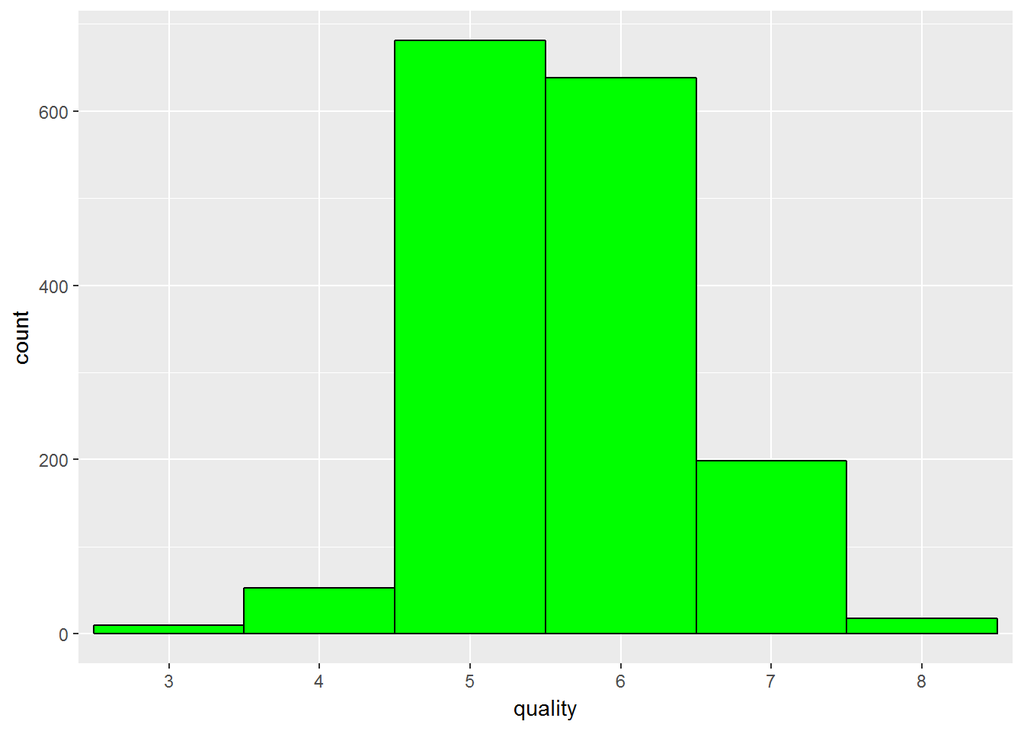

quality is a normal distribution but a very high peak at 5 and 6.

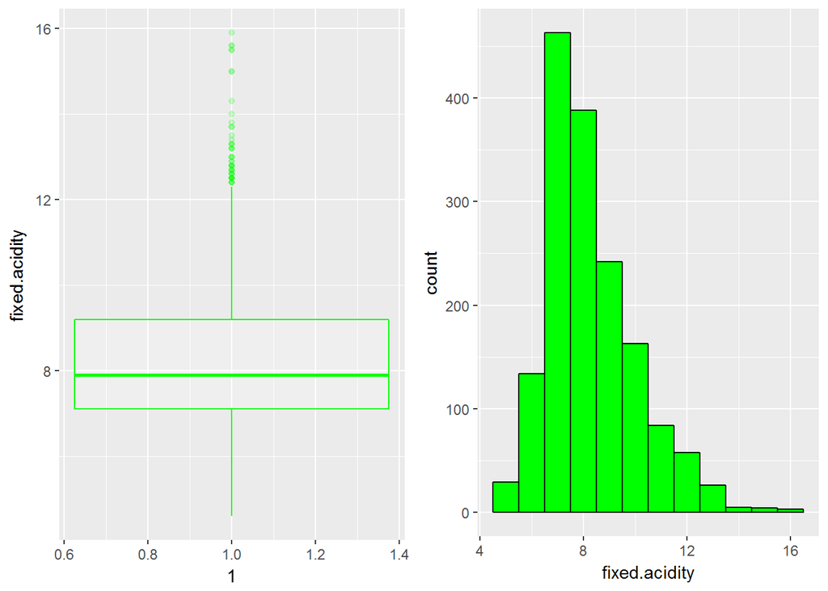

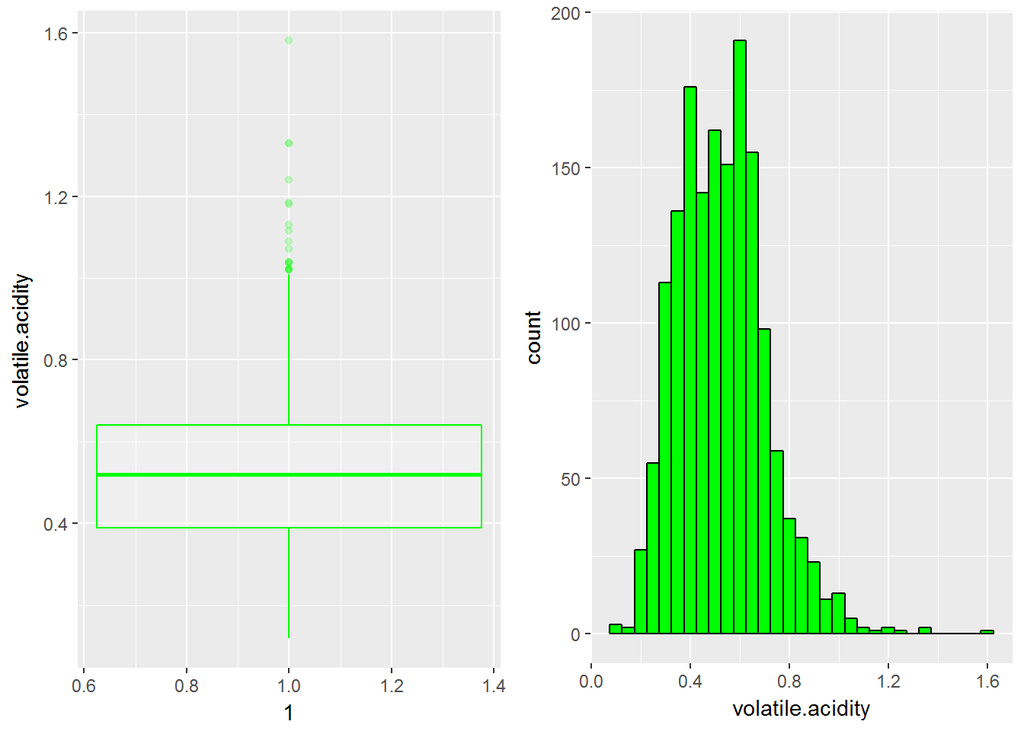

volitile.acidity seems to have a normal distribution but is positivly skewed because of some outlires.

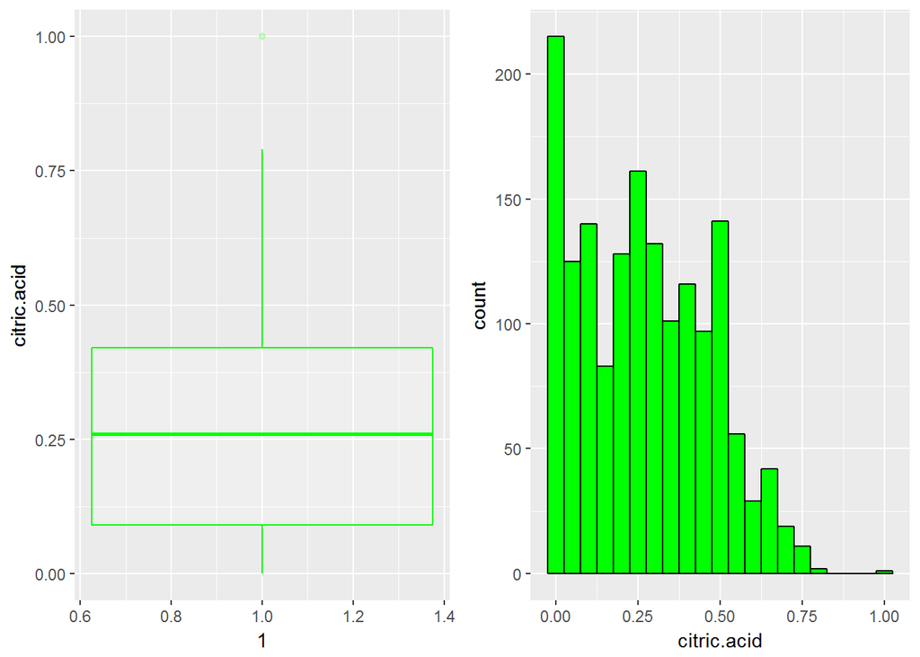

citric.acid looks strange. A lot of bottle didn’t have any citric acid and then it seemed to be a normal distribution. Was the data not complete or did a lot of sample not have citric acid?

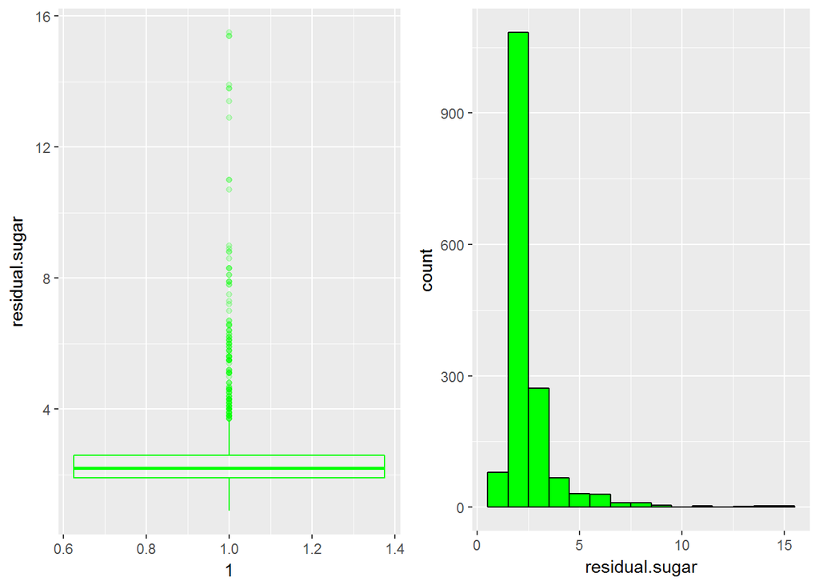

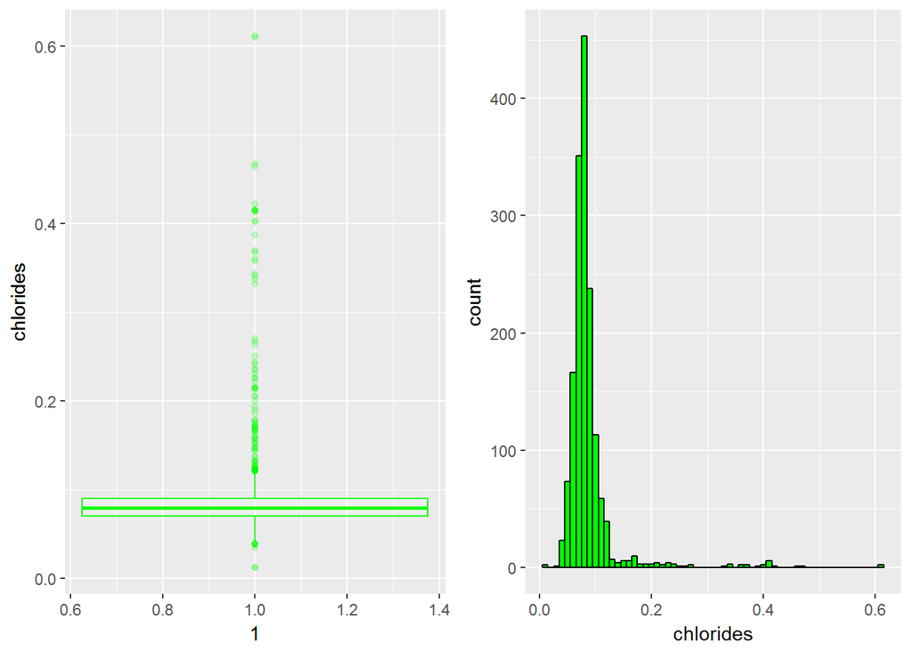

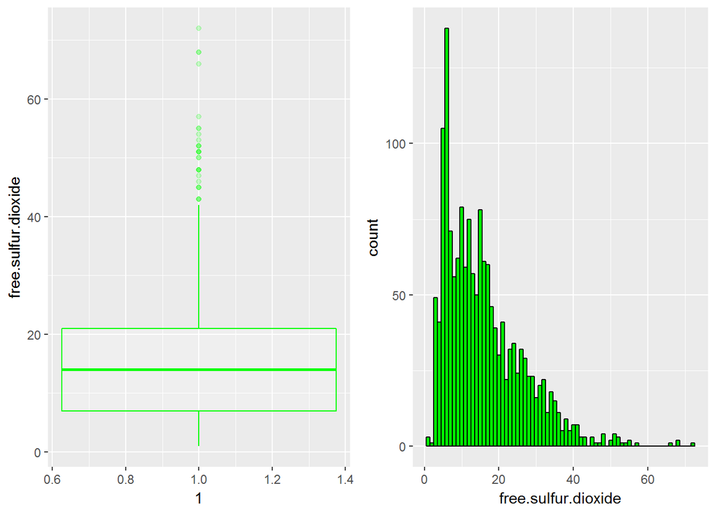

free.sulfur.dioxide has one tall peek then goes positively skewed from outliers

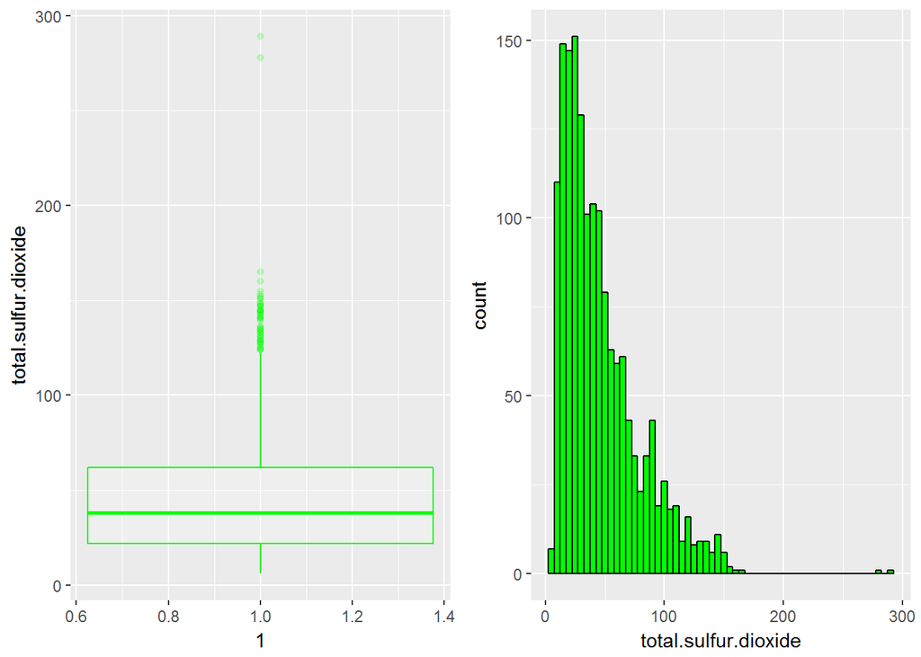

total.sulfur.dioxide has the same tall peek then goes positively skewed like the patterns we have been seeing.

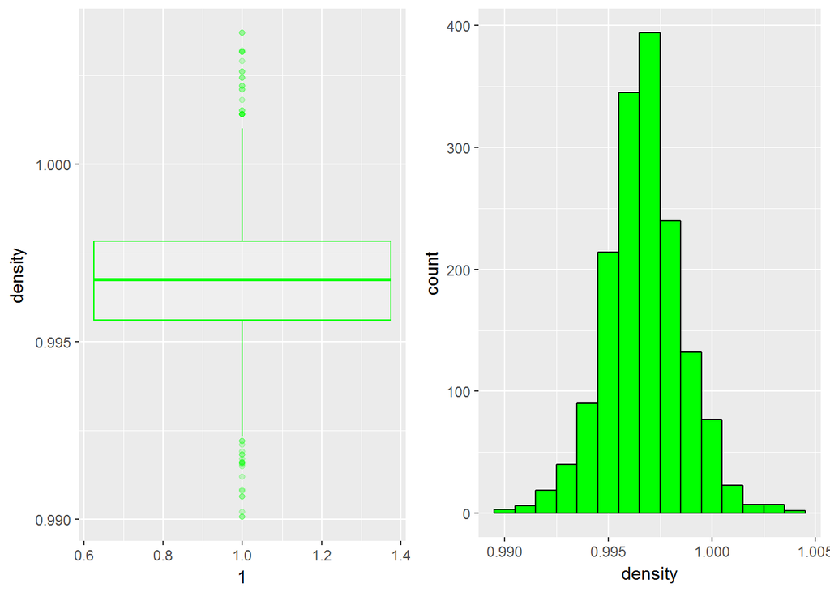

density has a normal distribution.

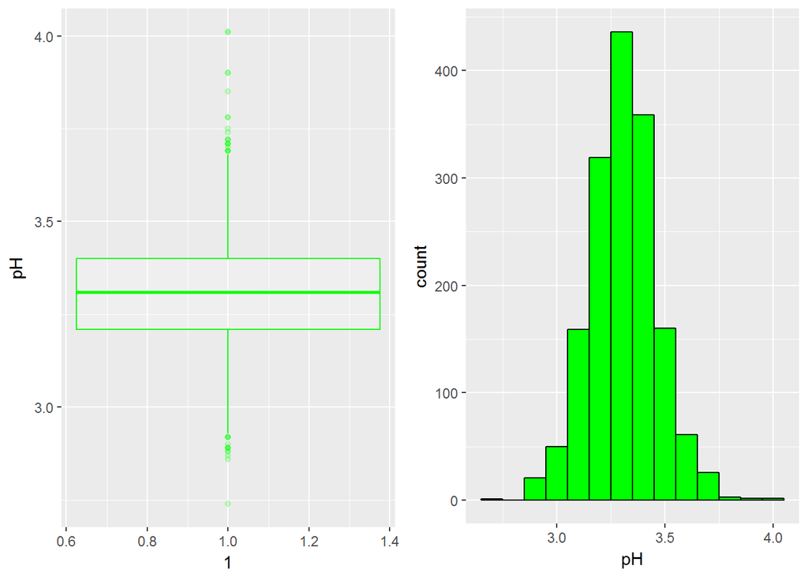

ph has a normal distribution.

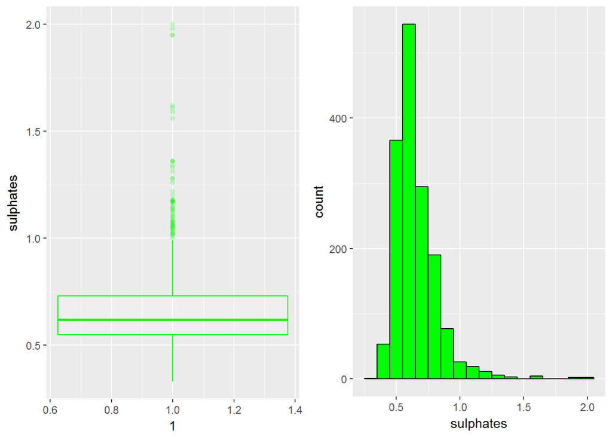

sulphates has the same positively skewed tail of outliers that a lot of the other variables have.

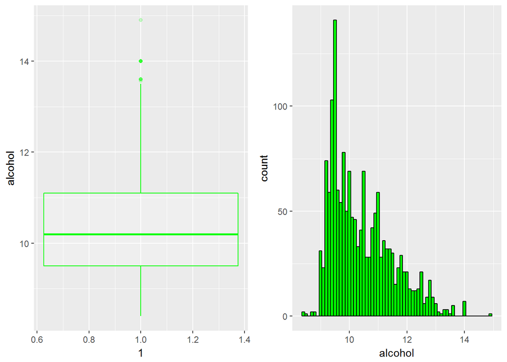

alchohol has a postivively skewed curve but doesn’t have the tail of outliers.

# Univariate Analysis

### Feature of Interest

The effect different variables have on quality.

### Hypothosis

I don’t drink wine so I can only guess at what makes wine taste better and have a better quality. I suspect that more alcohol will increase quality. Residual Sugar will have a positive impact of quality because sugar helps taste.

# Bivariate Plots Section

The first step I will take is to make a corrilation table to see where I will start my investigation. Finding high positive or negative corrilations will point me in the right dirction.

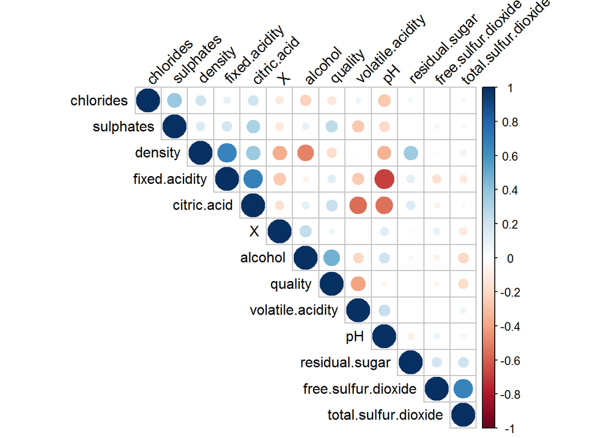

From the graph above we learn some things. 1. quality is most corillated with alcohol and volatile.acid 2. quality is corrilated with citric.acid and sulphates. 3. fixed.acidity has a very strong corrilation with pH. 4. pH and volatile.acid have a positive corrilation which is weird becasue acid has a negative corrilation with pH.

# Bivariate Analysis

I will now create some boxplots to see if I have missed anything from the correlation table.

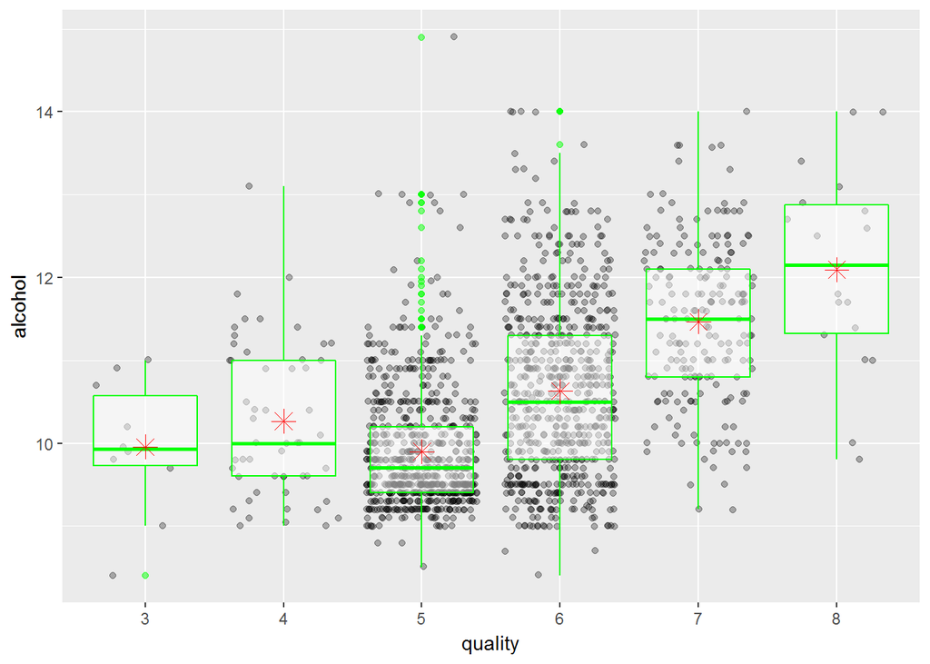

1. Alcohol and Quality has the best positive correlation at 0.4761. As you can see from the graph above as alcohol content goes up the quality of the wine goes up.

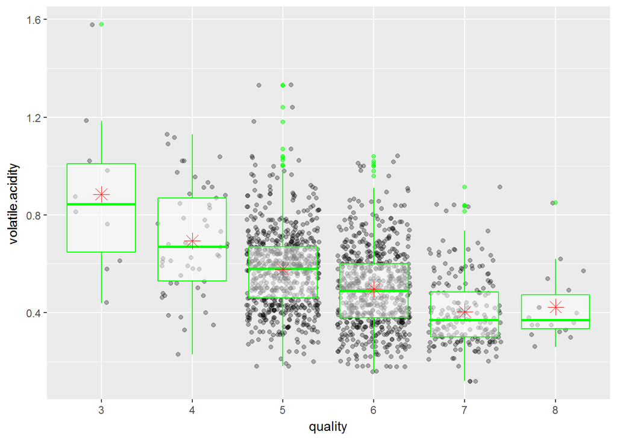

2. volatile.acidity and Quality have the best negative correlation at -0.3905. As volatile.acidity goes down the quality of wine goes up.

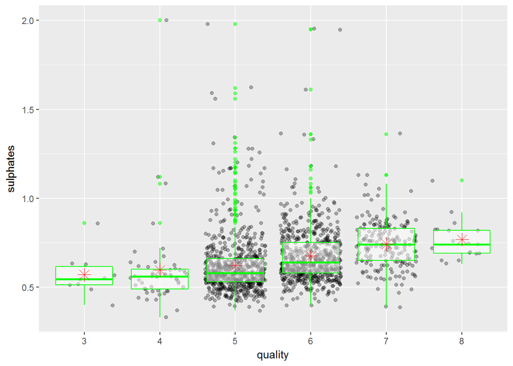

3. sulphates has a positive corrilation with quality at 0.2413 as seen in the graph above.

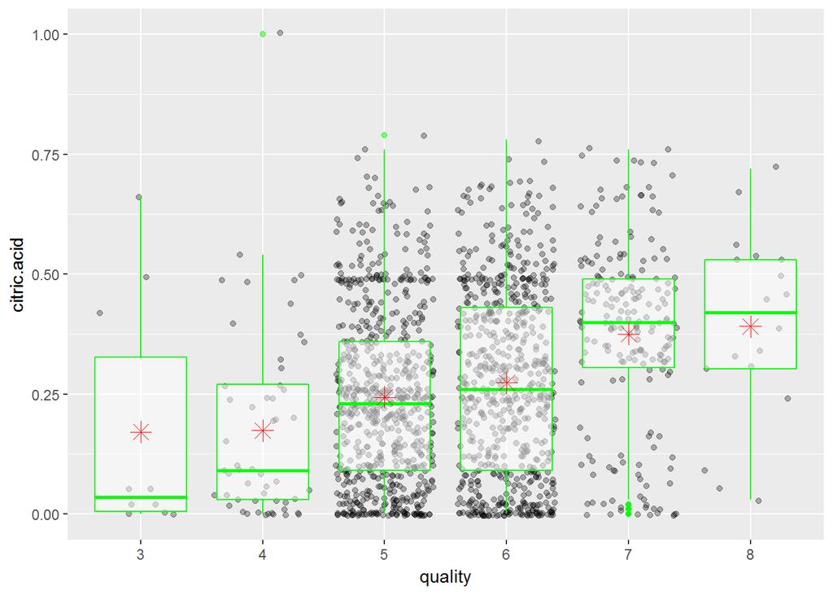

4. citric.acid has a positive corrilation with quality at 0.2263 as shown in the graph above.

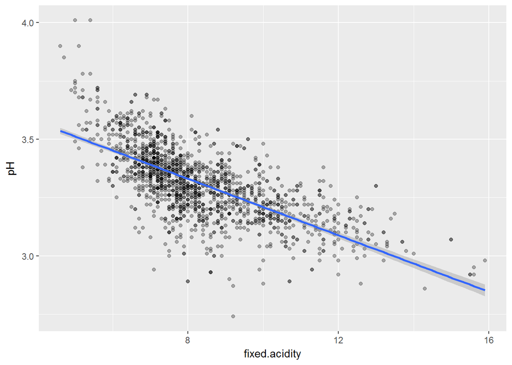

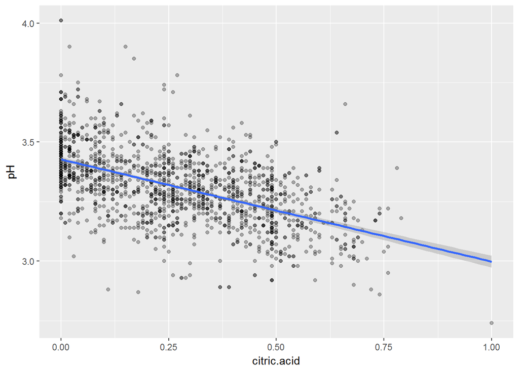

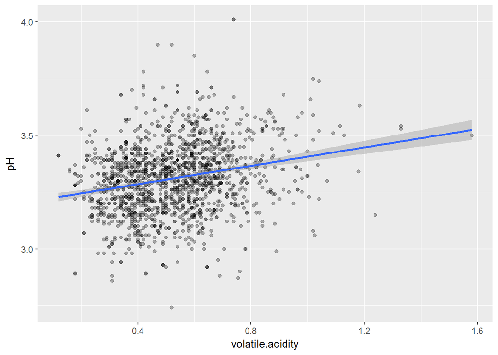

5. pH has a negative correlation with fixed.acidity and citric.acid. This makes sence since low pH numbers means more acidic. The more citric.acid in the wine the lower the pH. But volitile.acidity and pH have a positive correlation.  
   This is really weird because the more acid you have should decrease the you pH.  
   I will need to look into this using the simpons paradox and see if there is another variable that is changing the coefficient.

[output not shown]

[output not shown]

[output not shown]

[output not shown]

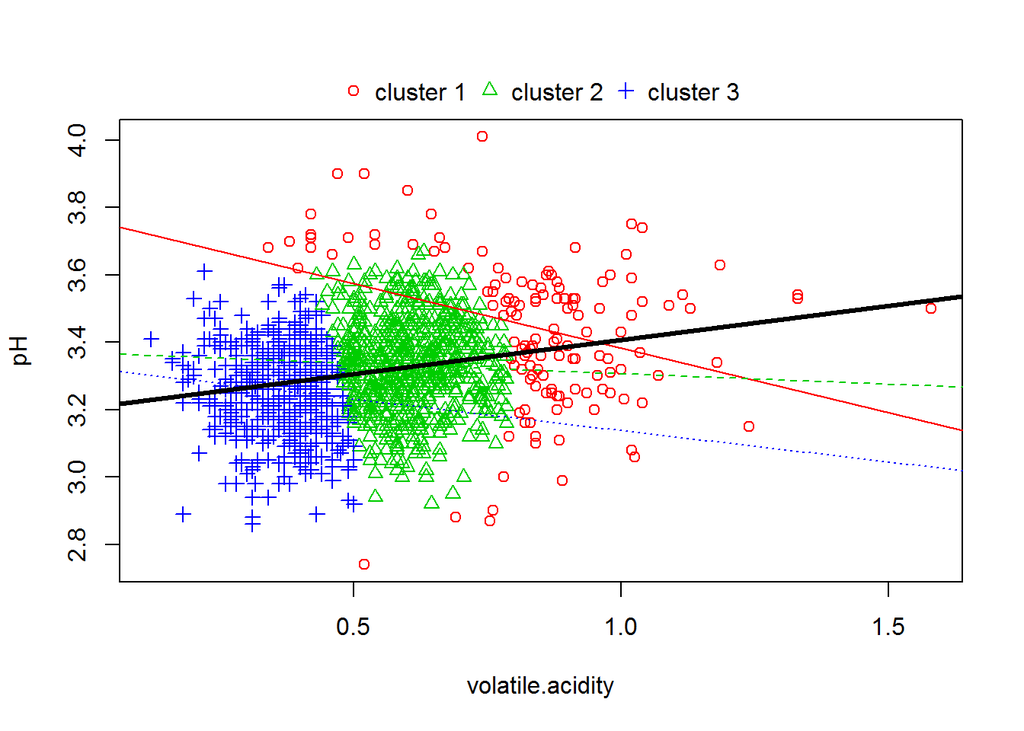

I clustered the data into 3 segments and calculated the regression coefficient. I see that there is indeed a sign reversal. This is due to a lurking variable which changes the overall coefficient.

# Multivariate Plots Section

Alcohol has the biggest correlation to quality of wine. We will not look to see if any other variables contribute to quality of wine if alcohol stays constant.

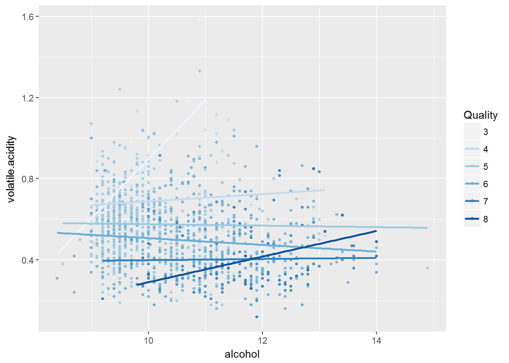

We can see that less volatile.acidity improves quality when alcohol is constant.

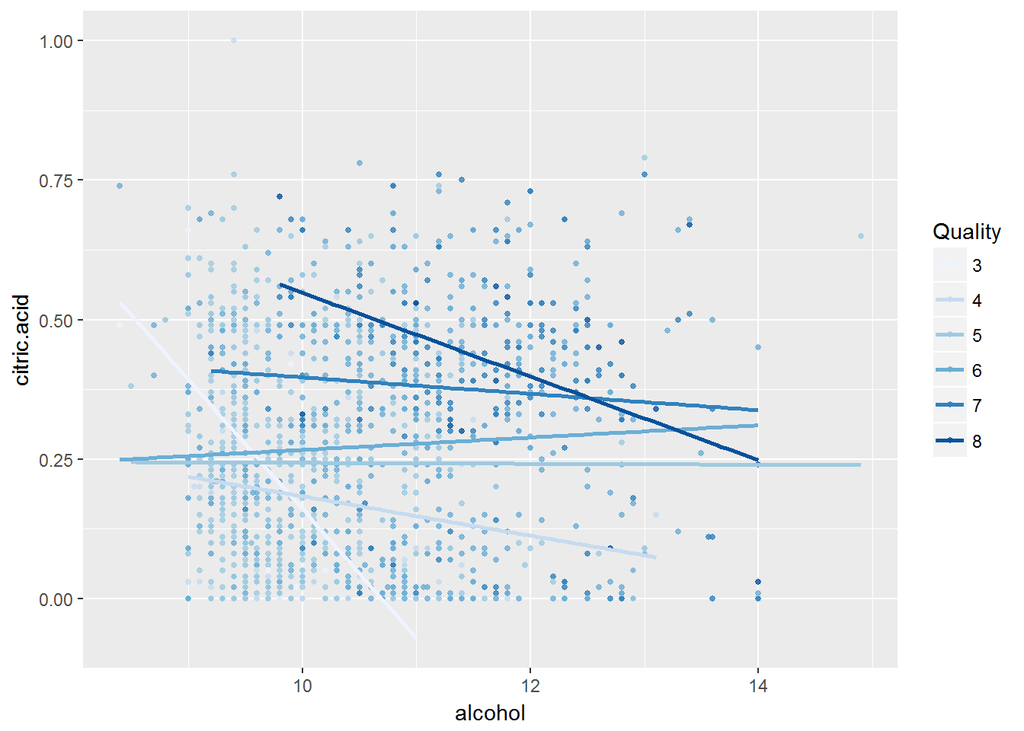

In the graph above we see that higher quality of wine comes from higher citric.acid content when alcohol is constant.

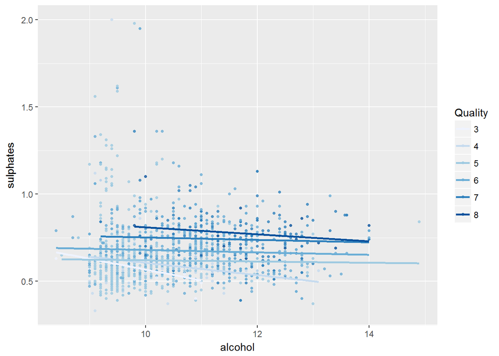

When sulphates and alcohol are at a higher concentration the quality of wine is better.

# Multivariate Analysis

1. High Alcohol and Sulaphate content seems to produce better wines.
2. Citric Acid, even though weakly correlated plays a part in improving the wine quality.

# Final Plots and Summary

> **Tip**: You’ve done a lot of exploration and have built up an understanding of the structure of and relationships between the variables in your dataset. Here, you will select three plots from all of your previous exploration to present here as a summary of some of your most interesting findings. Make sure that you have refined your selected plots for good titling, axis labels (with units), and good aesthetic choices (e.g. color, transparency). After each plot, make sure you justify why you chose each plot by describing what it shows.

### Plot One

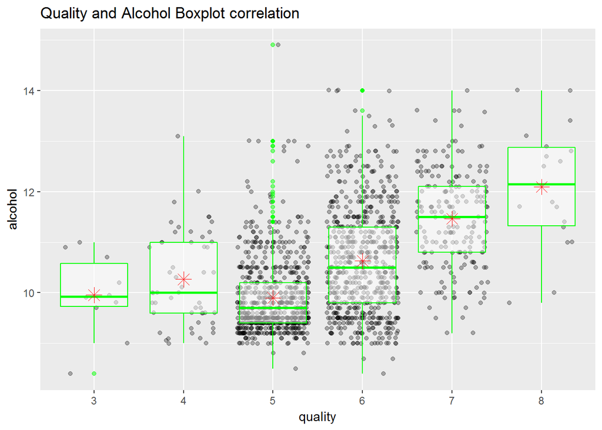

### Description One

This plot shows us the positive corrilation between alcohol and quality. The higher the alcohol content the higher the quality of wine. You can also see from this graph that the distribution normal with a high median of alcohol implies great wine.

### Plot Two

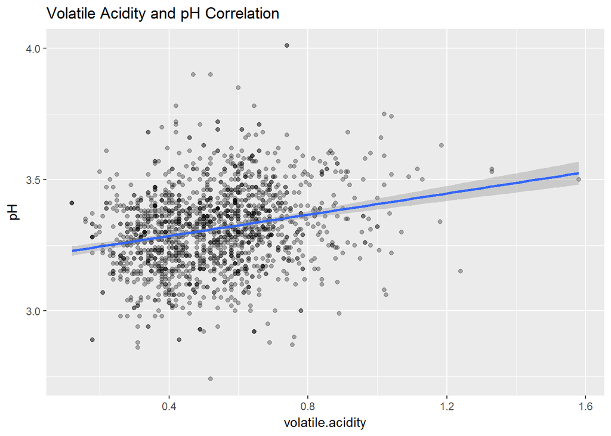

### Description Two

This plot shows us the weird positive corrilation between pH and volatile.acidity. This didn’t make sense because we know that acids have a negative correlation with pH. The more acid the lower the pH. In order to figure this out we looke towards the Simpson paradox and determined there was an underlying variable that was causing this positive corrilation between pH and volatile.acidity.

### Plot Three

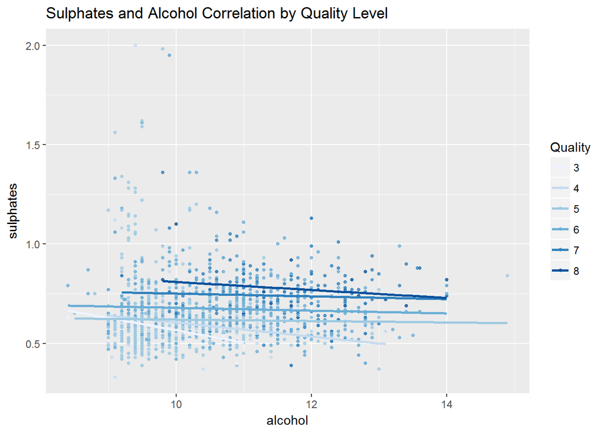

### Description Three

From this graph we can see higher quality of wines contain high values of alcohol and sulphates. This implys that higher concentrations of alcohol and sulphates increase wine quality. There is a downward slope, even if is very slight that might indicate that higher alcohol is a little better then higher sulphates.

# Reflection

So when I first started to look at the data and plot out the variables I noticed that most of the data was average quality of wine with very few bad and great quality of wines. This helped in showing a normal distribution but it was not a great representation for trying to determine what variables effected quality of wine. This caused some trouble with some of the variables like citric.acid which had a lot of zeros in the data. I couldn’t tell if the data was incomplete or if there were a lot of wine with no citric.acid in them.

When I started to look at the correlation between the variables a very weird result came up. It seemed that pH and volitile acid had a positve correlation.  
This meant that as more acid was added pH would become more basic.  
This is obviously wrong. I need to look into this so I started reading about this phenomenom and discovered the Simpson paradox. I was able to apply this principle and determine that there were other variables that were causing the positive correlation between volatile acid and pH.

Something that would be fun to look into would be how wine determined to be of quality by a taster. You could have a little survey with a couple of reponses and see if a certain sense played a factor or if a taster was bias towards certain types of wine.